# I. Network analysis of liver expression data from female mice: finding modules related to body weight

- Show All Code
- Hide All Code
- View Source

Author

TigerZ

Published

2023-08-07

**雌性小鼠肝脏表达数据的网络分析：寻找与体重相关的模块**

导入相关package：

```r
library(WGCNA)
```

## 1 Data input, cleaning and pre-processing

**1 数据输入、清洗和预处理**

这是任何网络分析的第一步。我们在这里展示如何加载典型的表达数据，将它们预处理成适合网络分析的格式，并通过删除明显的离群样本以及基因和缺失条目数量过多的样本来清理数据。

### 1.a Loading expression data

**1.a 加载表达数据**

表达数据包含在本教程附带的 LiverFemale3600.csv 文件中。

下载tutorial数据：[zipped data sets](https://horvath.genetics.ucla.edu/html/CoexpressionNetwork/Rpackages/WGCNA/Tutorials/FemaleLiver-Data.zip)

```r
# 导入 female liver 数据集
femData = read.csv("FemaleLiver-Data/LiverFemale3600.csv")
```

```r
# 查看数据维度
dim(femData)
```

```
[1] 3600  143
```

表达数据集包含 135 个样本。请注意，每行对应一个 gene，每列对应 sample 和其他辅助信息。

```r
# 查看数据内容
head(femData)
```

| substanceBXH | gene_symbol | LocusLinkID | ProteomeID | cytogeneticLoc | CHROMOSOME | StartPosition | EndPosition | F2_2 | F2_3 | F2_14 | F2_15 | F2_19 | F2_20 | F2_23 | F2_24 | F2_26 | F2_37 | F2_42 | F2_43 | F2_45 | F2_46 | F2_47 | F2_48 | F2_51 | F2_52 | F2_54 | F2_63 | F2_65 | F2_66 | … |
| --- | --- | --- | --- | --- | --- | --- | --- | --- | --- | --- | --- | --- | --- | --- | --- | --- | --- | --- | --- | --- | --- | --- | --- | --- | --- | --- | --- | --- | --- | --- |
| MMT00000044 | 1700007N18Rik | 69339 | 286025 | 0 | 16 | 50911260 | 50912491 | -0.01810 | 0.0642 | 6.44e-05 | -0.05800 | 0.04830 | -0.1519741 | -0.00129 | -0.23600 | -0.0307 | -0.02610 | 0.0737059 | -0.0466 | -0.00673 | -0.0193 | 0.09040 | 0.0290 | 0.0356 | -0.0388 | -0.0360 | -0.05600 | 0.009840 | -0.0261 | … |
| MMT00000046 | Mast2 | 17776 | 157466 | 0 | 4 | 115215318 | 115372404 | -0.07730 | -0.0297 | 1.12e-01 | -0.05890 | 0.04430 | -0.0938000 | 0.09340 | 0.02690 | -0.1330 | 0.07570 | -0.0091938 | -0.0075 | 0.01700 | 0.0722 | -0.08390 | 0.0273 | -0.0784 | -0.0178 | 0.1120 | 0.12300 | 0.051700 | 0.0731 | … |
| MMT00000051 | Ankrd32 | 105377 | 321939 | 0 | 13 | 74940309 | 74982847 | -0.02260 | 0.0617 | -1.29e-01 | 0.08710 | -0.11500 | -0.0650261 | 0.00249 | -0.10200 | 0.1420 | -0.10200 | 0.0642893 | 0.0169 | -0.01590 | -0.1430 | -0.00492 | -0.0735 | 0.0657 | -0.0197 | -0.1290 | -0.14300 | -0.061600 | 0.0419 | … |
| MMT00000076 | 0 | 383154 | 0 | 0 | 16 | 49345114 | 49477048 | -0.00924 | -0.1450 | 2.87e-02 | -0.04390 | 0.00425 | -0.2361000 | -0.06900 | 0.01440 | 0.0363 | -0.01820 | 0.4778746 | 0.1440 | 0.11100 | 0.0113 | 0.11900 | 0.0225 | 0.0932 | 0.1430 | 0.2640 | -0.09280 | -0.000635 | -0.0126 | … |
| MMT00000080 | Ldb2 | 16826 | 157383 | 0 | 5 | 43546124 | 43613704 | -0.04870 | 0.0582 | -4.83e-02 | -0.03710 | 0.02510 | 0.0850427 | 0.04450 | 0.00167 | -0.0680 | 0.00567 | -0.0753487 | -0.0673 | -0.04720 | 0.0701 | -0.08790 | -0.0180 | -0.1290 | -0.0469 | -0.0352 | -0.00166 | 0.058700 | -0.0206 | … |
| MMT00000102 | Rdhs | 216453 | 0 | 10_70.0_cM | 10 | 1337265 | 1347607 | 0.17600 | -0.1890 | -6.50e-02 | -0.00846 | -0.00574 | -0.0180718 | -0.12500 | -0.06820 | 0.1250 | 0.00998 | -0.0373666 | -0.0402 | -0.02190 | 0.0269 | 0.13300 | 0.0732 | 0.1070 | -0.0362 | -0.0696 | -0.19400 | -0.117000 | -0.0400 | … |

我们现在删除辅助数据并转置表达数据以进行进一步分析：datExpr0 行为 135 个样本，列为 3600 个 gene。

```r
datExpr0 = as.data.frame(t(femData[, -c(1:8)]))
colnames(datExpr0) = femData$substanceBXH
rownames(datExpr0) = colnames(femData)[-c(1:8)]
dim(datExpr0)
```

```
[1]  135 3600
```

### 1.b Checking data for excessive missing values and identification of outlier microarray samples

**1.b 检查数据是否有过度的缺失值和识别离群微阵列样本**

我们首先检查缺失值过多的基因和样本：

```r
gsg = goodSamplesGenes(datExpr0, verbose = 3)
```

```
 Flagging genes and samples with too many missing values...
  ..step 1
```

```r
gsg$allOK
```

```
[1] TRUE
```

如果 gsg$allOK 的结果为 TRUE，证明没有缺失值，可以直接下一步。如果为 FALSE，则需要用以下函数进行删除缺失值：

```r
if (!gsg$allOK){
  # 可选，打印已删除的 gene 和 sample 名称：
  if (sum(!gsg$goodGenes)>0)
  printFlush(paste("Removing genes:", paste(names(datExpr0)[!gsg$goodGenes], collapse = ", ")));
  if (sum(!gsg$goodSamples)>0)
  printFlush(paste("Removing samples:", paste(rownames(datExpr0)[!gsg$goodSamples], collapse = ", ")));
  # 从数据中删除有问题的 gene 和 sample：
  datExpr0 = datExpr0[gsg$goodSamples, gsg$goodGenes]
}
```

接下来我们对样本进行聚类,以查看是否有任何明显的异常值

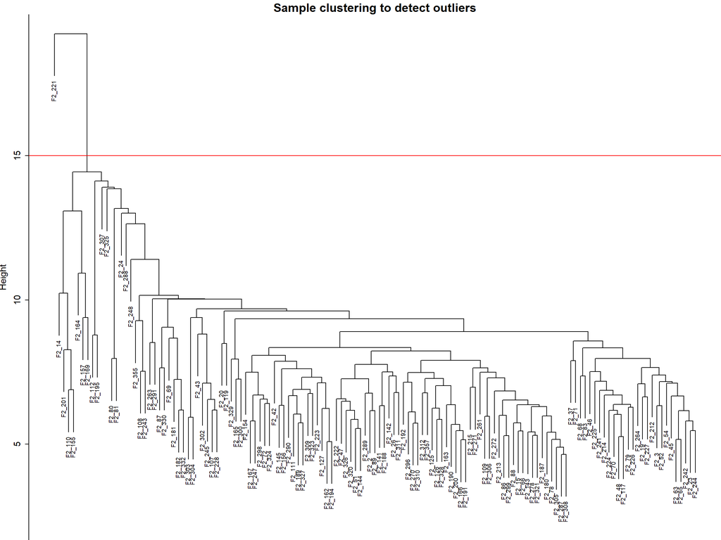

```r
sampleTree = hclust(dist(datExpr0), method = "average");
# 绘制示例树：打开尺寸为 12 x 9 英寸的图形输出窗口
# 如果窗口太大或太小，用户应该更改尺寸。
#sizeGrWindow(12,9)
#pdf(file = "Plots/sampleClustering.pdf", width = 12, height = 9);
par(cex = 0.6);
par(mar = c(0,4,2,0))
plot(sampleTree, main = "Sample clustering to detect outliers", sub="", xlab="",
     cex.lab = 1.5,cex.axis = 1.5, cex.main = 2)
# Plot a line to show the cut
abline(h = 15, col = "red");
```

```r
# 确定线下 cluster
clust = cutreeStatic(sampleTree, cutHeight = 15, minSize = 10)
table(clust)
```

```
clust
  0   1
  1 134
```

```r
# clust 1 包含我们想要保留的样本
keepSamples = (clust==1)
datExpr = datExpr0[keepSamples, ]
nGenes = ncol(datExpr)
nSamples = nrow(datExpr)
```

变量 datExpr 现在包含可供网络分析使用的表达数据。

### 1.c Loading clinical trait data

**1.c 加载临床特征数据**

我们现在读入特征数据，并将它们与表达量样本匹配

```r
traitData = read.csv("FemaleLiver-Data/ClinicalTraits.csv");
# 删除包含我们不需要的信息的列。
allTraits = traitData[, -c(31, 16)];
allTraits = allTraits[, c(2, 11:36) ];
# 形成类似于表达数据的数据框，以保存临床特征。
femaleSamples = rownames(datExpr);
traitRows = match(femaleSamples, allTraits$Mice)
datTraits = allTraits[traitRows, -1]
rownames(datTraits) = allTraits[traitRows, 1]
collectGarbage()
```

我们现在在变量 datExpr 中有表达量数据，在变量 datTraits 中有相应的特征数据。 在我们继续网络构建和模块检测之前，我们将特征与样本树状图的关系可视化。

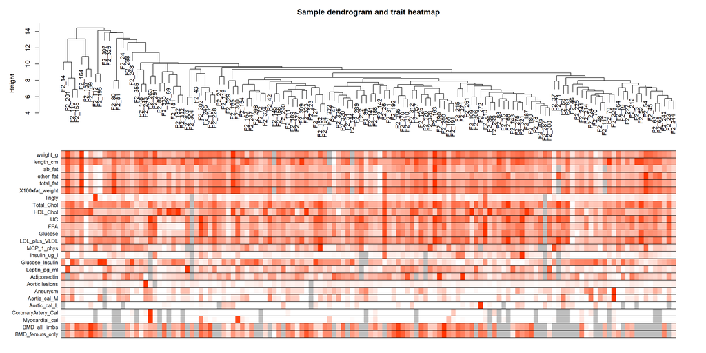

```r
# Re-cluster samples
sampleTree2 = hclust(dist(datExpr), method = "average")
# 将特征转换为颜色表示：白色表示低，红色表示高，灰色表示缺失条目
traitColors = numbers2colors(datTraits, signed = FALSE);
# 绘制样本树状图和下面的颜色
plotDendroAndColors(sampleTree2, traitColors, groupLabels = names(datTraits),
                    main = "Sample dendrogram and trait heatmap")
```

最后一步是保存相关的表达式和特征数据，以便在教程的后续步骤中使用。

```r
save(datExpr, datTraits, file = "FemaleLiver-01-dataInput.RData")
```

## 2 Network construction and module detection

**2 网络构建及模块检测**

此步骤是使用 WGCNA 方法进行所有网络分析的基础。作者提出了构建网络和识别模块的三种不同方法： a. 采用便捷的一步网络构建和模块检测功能，适合希望事半功倍的用户； b. 逐步的网络构建和模块检测，适合想要尝试定制/替代方法的用户； c. 一个自动分块网络构建和模块检测方法，适合希望分析太大而无法一次性分析的数据集的用户。

准备工作：

```r
# 开启多线程
enableWGCNAThreads()
```

```
Allowing parallel execution with up to 15 working processes.
```

```r
# 载入第一步保存的数据
lnames = load(file = "FemaleLiver-01-dataInput.RData");
lnames
```

```
[1] "datExpr"   "datTraits"
```

我们已经加载了分别包含表达量和特征数据的变量 datExpr 和 datTraits。

### 2.a Automatic network construction and module detection

**2.a 自动网络构建和模块检测**

#### 2.a.1 Choosing the soft-thresholding power: analysis of network topology

**2.a.1 选择软阈值幂：网络拓扑分析**

构建加权基因网络需要选择软阈值幂 β，通过提高共表达相似度来计算邻接度(djacency)。 作者提出基于近似无标度拓扑的标准来选择软阈值能力。我们建议读者参阅该著作以了解更多详细信息；在这里，我们演示了 `pickSoftThreshold` 函数的使用，该函数执行网络拓扑分析并帮助用户选择合适的软阈值幂。用户选择一组候选幂（该函数提供合适的默认值），该函数返回一组应检查的网络索引，例如如下：

```r
# Choose a set of soft-thresholding powers
powers = c(c(1:10), seq(from = 12, to=20, by=2))
# Call the network topology analysis function
sft = pickSoftThreshold(datExpr, powerVector = powers, verbose = 5)
```

```
pickSoftThreshold: will use block size 3600.
 pickSoftThreshold: calculating connectivity for given powers...
   ..working on genes 1 through 3600 of 3600
   Power SFT.R.sq  slope truncated.R.sq mean.k. median.k. max.k.
1      1   0.0278  0.345          0.456  747.00  762.0000 1210.0
2      2   0.1260 -0.597          0.843  254.00  251.0000  574.0
3      3   0.3400 -1.030          0.972  111.00  102.0000  324.0
4      4   0.5060 -1.420          0.973   56.50   47.2000  202.0
5      5   0.6810 -1.720          0.940   32.20   25.1000  134.0
6      6   0.9020 -1.500          0.962   19.90   14.5000   94.8
7      7   0.9210 -1.670          0.917   13.20    8.6800   84.1
8      8   0.9040 -1.720          0.876    9.25    5.3900   76.3
9      9   0.8590 -1.700          0.836    6.80    3.5600   70.5
10    10   0.8330 -1.660          0.831    5.19    2.3800   65.8
11    12   0.8530 -1.480          0.911    3.33    1.1500   58.1
12    14   0.8760 -1.380          0.949    2.35    0.5740   51.9
13    16   0.9070 -1.300          0.970    1.77    0.3090   46.8
14    18   0.9120 -1.240          0.973    1.39    0.1670   42.5
15    20   0.9310 -1.210          0.977    1.14    0.0951   38.7
```

```r
# Plot the results:
#sizeGrWindow(9, 5)
par(mfrow = c(1,2));
cex1 = 0.9;
# Scale-free topology fit index as a function of the soft-thresholding power
plot(sft$fitIndices[,1], -sign(sft$fitIndices[,3])*sft$fitIndices[,2],
xlab="Soft Threshold (power)",ylab="Scale Free Topology Model Fit,signed R^2",type="n",
main = paste("Scale independence"));
text(sft$fitIndices[,1], -sign(sft$fitIndices[,3])*sft$fitIndices[,2],
labels=powers,cex=cex1,col="red");
# this line corresponds to using an R^2 cut-off of h
abline(h=0.90,col="red")
# Mean connectivity as a function of the soft-thresholding power
plot(sft$fitIndices[,1], sft$fitIndices[,5],
xlab="Soft Threshold (power)",ylab="Mean Connectivity", type="n",
main = paste("Mean connectivity"))
text(sft$fitIndices[,1], sft$fitIndices[,5], labels=powers, cex=cex1,col="red")
```

[output not shown]

```r
sft$powerEstimate
```

```
[1] 6
```

如果显示的结果为 NA，则表明系统无法给出合适的软阈值，这时候就需要自己挑选软阈值。 手动挑选软阈值的大致规则如上面所述。

#### 2.a.2 One-step network construction and module detection

**2.a.2 一步网络构建及模块检测**

构建基因网络和识别模块现在是一个简单的函数调用：

```r
net = blockwiseModules(datExpr, power = 6,
                       TOMType = "unsigned", minModuleSize = 30,
                       reassignThreshold = 0, mergeCutHeight = 0.25,
                       numericLabels = TRUE, pamRespectsDendro = FALSE,
                       saveTOMs = TRUE,
                       saveTOMFileBase = "femaleMouseTOM",
                       verbose = 3)
```

```
 Calculating module eigengenes block-wise from all genes
   Flagging genes and samples with too many missing values...
    ..step 1
Cluster size 3600 broken into 2108 1492
Cluster size 2108 broken into 1126 982
Done cluster 1126
Done cluster 982
Done cluster 2108
Done cluster 1492
 ..Working on block 1 .
    TOM calculation: adjacency..
    ..will not use multithreading.
     Fraction of slow calculations: 0.396405
    ..connectivity..
    ..matrix multiplication (system BLAS)..
    ..normalization..
    ..done.
   ..saving TOM for block 1 into file femaleMouseTOM-block.1.RData
 ....clustering..
 ....detecting modules..
 ....calculating module eigengenes..
 ....checking kME in modules..
     ..removing 1 genes from module 1 because their KME is too low.
     ..removing 1 genes from module 7 because their KME is too low.
     ..removing 1 genes from module 8 because their KME is too low.
     ..removing 1 genes from module 21 because their KME is too low.
 ..merging modules that are too close..
     mergeCloseModules: Merging modules whose distance is less than 0.25
       Calculating new MEs...
```

```r
# 参数解释
# power = 6 是刚才选择的软阈值
# minModuleSize：模块中最少的基因数
# mergeCutHeight：模块合并阈值，阈值越大，模块越少
# saveTOMs = TRUE, saveTOMFileBase = "femaleMouseTOM" 保存 TOM 矩阵，名字为"femaleMouseTOM"
# net$colors 包含模块分配，net$MEs 包含模块的模块特征基因。
```

```r
table(net$colors)
```

```
  0   1   2   3   4   5   6   7   8   9  10  11  12  13  14  15  16  17  18
 99 609 460 409 316 312 221 211 157 123 106 100  94  91  77  76  58  47  34
```

以上结果表示一共可以分为 18 个模块，模块 0 是无法识别的基因，从模块 1 开始，基因数逐渐减少。

模块标识的层次聚类树状图，可以使用以下代码将树状图与颜色分配一起显示：

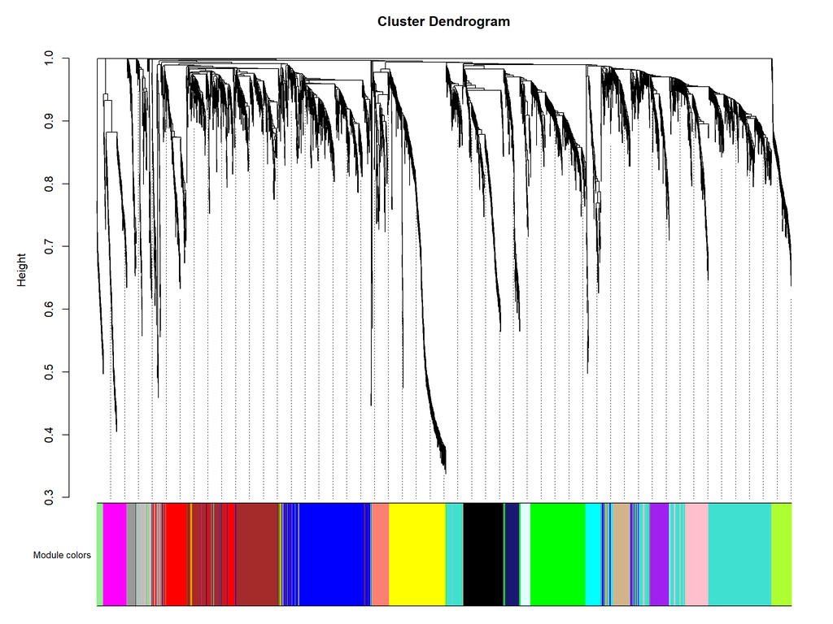

```r
# open a graphics window
#sizeGrWindow(12, 9)
# Convert labels to colors for plotting
mergedColors = labels2colors(net$colors)
# Plot the dendrogram and the module colors underneath
plotDendroAndColors(net$dendrograms[[1]], mergedColors[net$blockGenes[[1]]],
                    "Module colors",
                    dendroLabels = FALSE, hang = 0.03,
                    addGuide = TRUE, guideHang = 0.05)
```

如果需要修改树、模块成员、和模块合并标准，该包的 `recutBlockwiseTrees` 函数可以对结果进行修改，而无需重复计算网络和树状图。（推荐用第二种方法分步法实现）

保存分配模块和模块包含的基因信息。

```r
moduleLabels = net$colors
moduleColors = labels2colors(net$colors)
MEs = net$MEs;
geneTree = net$dendrograms[[1]];
save(MEs, moduleLabels, moduleColors, geneTree,
     file = "FemaleLiver-02-networkConstruction-auto.RData")
```

### 2.b Step-by-step network construction and module detection

**2.b 逐步的网络构建和模块检测**

准备工作：

```r
# 开启多线程
enableWGCNAThreads()
```

```
Allowing parallel execution with up to 15 working processes.
```

```r
# 载入第一步保存的数据
lnames = load(file = "FemaleLiver-01-dataInput.RData");
lnames
```

```
[1] "datExpr"   "datTraits"
```

#### 2.b.1 Choosing the soft-thresholding power: analysis of network topology

**2.b.1 选择软阈值幂：网络拓扑分析**

```r
# Choose a set of soft-thresholding powers
powers = c(c(1:10), seq(from = 12, to=20, by=2))
# Call the network topology analysis function
sft = pickSoftThreshold(datExpr, powerVector = powers, verbose = 5)
```

```
pickSoftThreshold: will use block size 3600.
 pickSoftThreshold: calculating connectivity for given powers...
   ..working on genes 1 through 3600 of 3600
   Power SFT.R.sq  slope truncated.R.sq mean.k. median.k. max.k.
1      1   0.0278  0.345          0.456  747.00  762.0000 1210.0
2      2   0.1260 -0.597          0.843  254.00  251.0000  574.0
3      3   0.3400 -1.030          0.972  111.00  102.0000  324.0
4      4   0.5060 -1.420          0.973   56.50   47.2000  202.0
5      5   0.6810 -1.720          0.940   32.20   25.1000  134.0
6      6   0.9020 -1.500          0.962   19.90   14.5000   94.8
7      7   0.9210 -1.670          0.917   13.20    8.6800   84.1
8      8   0.9040 -1.720          0.876    9.25    5.3900   76.3
9      9   0.8590 -1.700          0.836    6.80    3.5600   70.5
10    10   0.8330 -1.660          0.831    5.19    2.3800   65.8
11    12   0.8530 -1.480          0.911    3.33    1.1500   58.1
12    14   0.8760 -1.380          0.949    2.35    0.5740   51.9
13    16   0.9070 -1.300          0.970    1.77    0.3090   46.8
14    18   0.9120 -1.240          0.973    1.39    0.1670   42.5
15    20   0.9310 -1.210          0.977    1.14    0.0951   38.7
```

```r
# Plot the results:
#sizeGrWindow(9, 5)
par(mfrow = c(1,2));
cex1 = 0.9;
# Scale-free topology fit index as a function of the soft-thresholding power
plot(sft$fitIndices[,1], -sign(sft$fitIndices[,3])*sft$fitIndices[,2],
xlab="Soft Threshold (power)",ylab="Scale Free Topology Model Fit,signed R^2",type="n",
main = paste("Scale independence"));
text(sft$fitIndices[,1], -sign(sft$fitIndices[,3])*sft$fitIndices[,2],
labels=powers,cex=cex1,col="red");
# this line corresponds to using an R^2 cut-off of h
abline(h=0.90,col="red")
# Mean connectivity as a function of the soft-thresholding power
plot(sft$fitIndices[,1], sft$fitIndices[,5],
xlab="Soft Threshold (power)",ylab="Mean Connectivity", type="n",
main = paste("Mean connectivity"))
text(sft$fitIndices[,1], sft$fitIndices[,5], labels=powers, cex=cex1,col="red")
```

[output not shown]

#### 2.b.2 Co-expression similarity and adjacency

**2.b.2 共表达相似性和邻接性**

我们现在使用软阈值幂 6 计算邻接：

```r
softPower = 6
adjacency = adjacency(datExpr, power = softPower)
```

#### 2.b.3 Topological Overlap Matrix (TOM)

**2.b.3 拓扑重叠矩阵（TOM）**

为了最大限度地减少噪声和虚假关联的影响，我们将邻接关系转换为拓扑重叠矩阵，并计算相应的相异度：

```r
# Turn adjacency into topological overlap
TOM = TOMsimilarity(adjacency);
```

```
..connectivity..
..matrix multiplication (system BLAS)..
..normalization..
..done.
```

```r
dissTOM = 1-TOM
```

#### 2.b.4 Clustering using TOM

**2.b.4 使用 TOM 进行聚类**

我们现在使用层次聚类来生成基因的层次聚类树（树状图）。请注意，我们使用的函数 hclust 提供了比标准 hclust 函数更快的层次聚类例程。

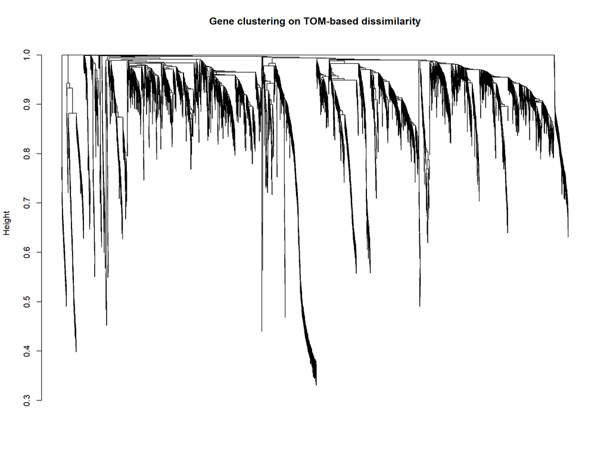

```r
# Call the hierarchical clustering function
geneTree = hclust(as.dist(dissTOM), method = "average");
# Plot the resulting clustering tree (dendrogram)
#sizeGrWindow(12,9)
plot(geneTree, xlab="", sub="", main = "Gene clustering on TOM-based dissimilarity",
labels = FALSE, hang = 0.04);
```

最后一个命令绘制的聚类树状图如图所示。在聚类树（树状图）中，每个叶子（即一条短垂直线）对应于一个基因。树状图组的分支紧密相连、高度共表达的基因。模块识别相当于识别各个分支（“从树形图上切掉分支”）。剪枝的方法有多种；我们的标准方法是来自包 `dynamicTreeCut` 的动态树切割。下一个代码片段说明了它的用法。

```r
# We like large modules, so we set the minimum module size relatively high:
minModuleSize = 30;
# Module identification using dynamic tree cut:
dynamicMods = cutreeDynamic(dendro = geneTree, distM = dissTOM,
                            deepSplit = 2, pamRespectsDendro=FALSE,
                            minClusterSize=minModuleSize)
```

```
 ..cutHeight not given, setting it to 0.996  ===>  99% of the (truncated) height range in dendro.
 ..done.
```

```r
table(dynamicMods)
```

```
dynamicMods
  0   1   2   3   4   5   6   7   8   9  10  11  12  13  14  15  16  17  18  19
 88 614 316 311 257 235 225 212 158 153 121 106 102 100  94  91  78  76  65  58
 20  21  22
 58  48  34
```

该函数返回 22 个模块，标记为 1-22 从大到小。标签0被保留给未分配的基因。上面的命令列出了模块的大小。我们现在在基因树图下绘制模块分配：

```r
# Convert numeric lables into colors
dynamicColors = labels2colors(dynamicMods)
table(dynamicColors)
```

```
dynamicColors
       black         blue        brown         cyan    darkgreen      darkred
         212          316          311           94           34           48
       green  greenyellow         grey       grey60    lightcyan   lightgreen
         235          106           88           76           78           65
 lightyellow      magenta midnightblue         pink       purple          red
          58          153           91          158          121          225
   royalblue       salmon          tan    turquoise       yellow
          58          100          102          614          257
```

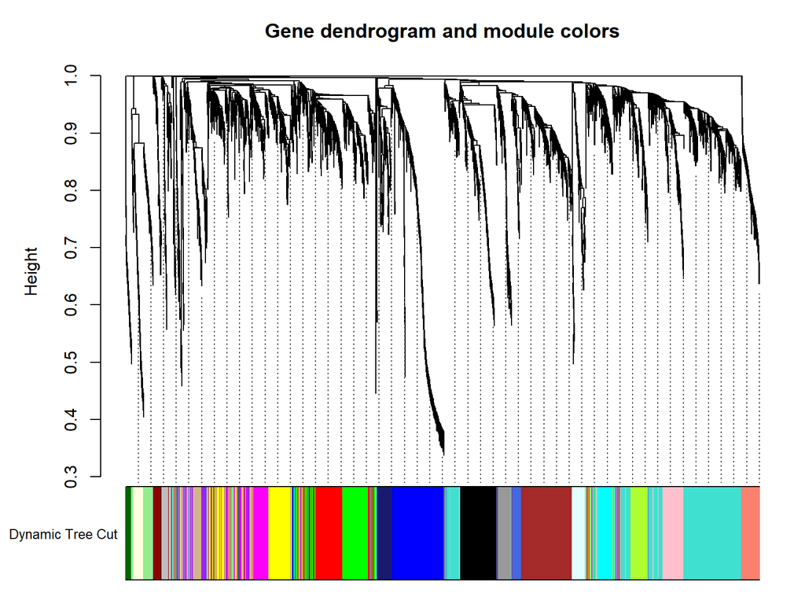

```r
# Plot the dendrogram and colors underneath
#sizeGrWindow(8,6)
plotDendroAndColors(geneTree, dynamicColors, "Dynamic Tree Cut",
dendroLabels = FALSE, hang = 0.03,
addGuide = TRUE, guideHang = 0.05,
main = "Gene dendrogram and module colors")
```

#### 2.b.5 Merging of modules whose expression profiles are very similar

**2.b.5 合并表达谱非常相似的模块**

动态树剪切可以识别其表达谱非常相似的模块。合并这些模块可能是谨慎的， 因为它们的基因是高度共表达的。为了量化整个模块的共表达相似性，我们计算了它们的 特征基因（eigengenes），并对它们的相关性进行了聚类：

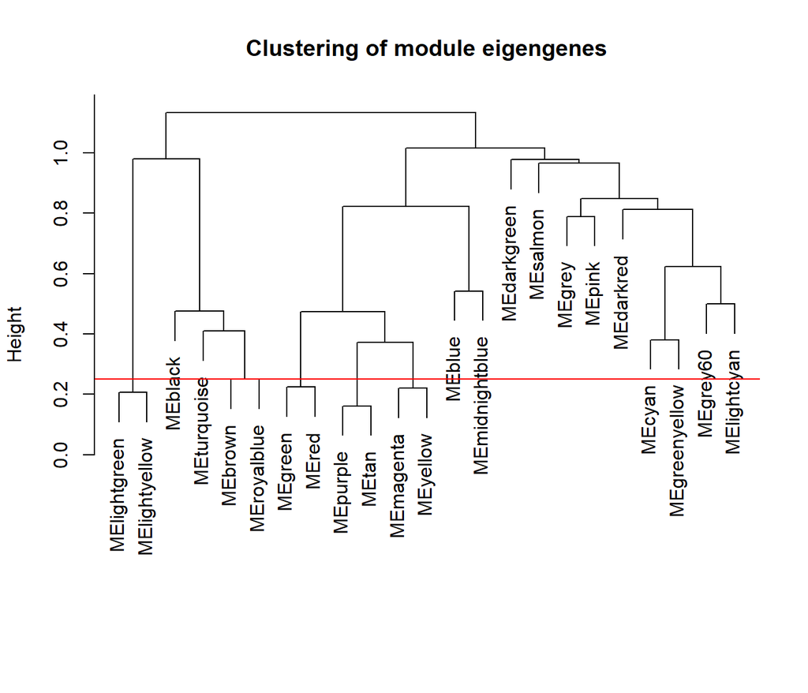

```r
# Calculate eigengenes
MEList = moduleEigengenes(datExpr, colors = dynamicColors)
MEs = MEList$eigengenes
# Calculate dissimilarity of module eigengenes
MEDiss = 1-cor(MEs);
# Cluster module eigengenes
METree = hclust(as.dist(MEDiss), method = "average");
# Plot the result
#sizeGrWindow(7, 6)
plot(METree, main = "Clustering of module eigengenes", xlab = "", sub = "")
MEDissThres = 0.25
# Plot the cut line into the dendrogram
abline(h=MEDissThres, col = "red")
```

我们选择一个 0.25 的高度切割，对应的相关性为 0.75，进行合并。

```r
# Call an automatic merging function
merge = mergeCloseModules(datExpr, dynamicColors, cutHeight = MEDissThres, verbose = 3)
```

```
 mergeCloseModules: Merging modules whose distance is less than 0.25
   multiSetMEs: Calculating module MEs.
     Working on set 1 ...
     moduleEigengenes: Calculating 23 module eigengenes in given set.
   multiSetMEs: Calculating module MEs.
     Working on set 1 ...
     moduleEigengenes: Calculating 19 module eigengenes in given set.
   Calculating new MEs...
   multiSetMEs: Calculating module MEs.
     Working on set 1 ...
     moduleEigengenes: Calculating 19 module eigengenes in given set.
```

```r
# The merged module colors
mergedColors = merge$colors;
# Eigengenes of the new merged modules:
mergedMEs = merge$newMEs
```

为了了解合并对我们的模块颜色做了什么，我们再次绘制了基因树状图，下面是原始的和合 并的模块颜色

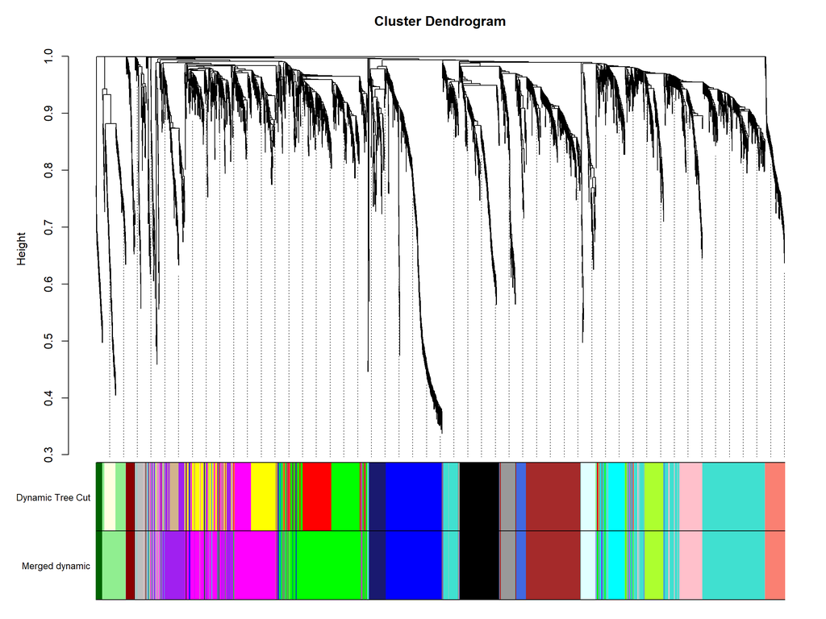

```r
#sizeGrWindow(12, 9)
#pdf(file = "Plots/geneDendro-3.pdf", wi = 9, he = 6)
plotDendroAndColors(geneTree, cbind(dynamicColors, mergedColors),
                    c("Dynamic Tree Cut", "Merged dynamic"),
                    dendroLabels = FALSE, hang = 0.03,
                    addGuide = TRUE, guideHang = 0.05)
```

```r
#dev.off()
```

在随后的分析中，我们将在合并的颜色中使用合并的模块颜色。我们将相关变量保存在本教 程的后续部分中使用：

```r
# Rename to moduleColors
moduleColors = mergedColors
# Construct numerical labels corresponding to the colors
colorOrder = c("grey", standardColors(50));
moduleLabels = match(moduleColors, colorOrder)-1;
MEs = mergedMEs;
# Save module colors and labels for use in subsequent parts
save(MEs, moduleLabels, moduleColors, geneTree,
     file = "FemaleLiver-02-networkConstruction-stepByStep.RData")
```

### 2.c Dealing with large datasets: block-wise network construction and module detection

**2.c 处理大型数据集：分块网络构建和模块检测**

准备工作：

```r
# 开启多线程
enableWGCNAThreads()
```

```
Allowing parallel execution with up to 15 working processes.
```

```r
# 载入第一步保存的数据
lnames = load(file = "FemaleLiver-01-dataInput.RData");
lnames
```

```
[1] "datExpr"   "datTraits"
```

#### 2.c.1 Choosing the soft-thresholding power: analysis of network topology

**2.c.1 选择软阈值幂：网络拓扑分析**

```r
# Choose a set of soft-thresholding powers
powers = c(c(1:10), seq(from = 12, to=20, by=2))
# Call the network topology analysis function
sft = pickSoftThreshold(datExpr, powerVector = powers, verbose = 5)
```

```
pickSoftThreshold: will use block size 3600.
 pickSoftThreshold: calculating connectivity for given powers...
   ..working on genes 1 through 3600 of 3600
   Power SFT.R.sq  slope truncated.R.sq mean.k. median.k. max.k.
1      1   0.0278  0.345          0.456  747.00  762.0000 1210.0
2      2   0.1260 -0.597          0.843  254.00  251.0000  574.0
3      3   0.3400 -1.030          0.972  111.00  102.0000  324.0
4      4   0.5060 -1.420          0.973   56.50   47.2000  202.0
5      5   0.6810 -1.720          0.940   32.20   25.1000  134.0
6      6   0.9020 -1.500          0.962   19.90   14.5000   94.8
7      7   0.9210 -1.670          0.917   13.20    8.6800   84.1
8      8   0.9040 -1.720          0.876    9.25    5.3900   76.3
9      9   0.8590 -1.700          0.836    6.80    3.5600   70.5
10    10   0.8330 -1.660          0.831    5.19    2.3800   65.8
11    12   0.8530 -1.480          0.911    3.33    1.1500   58.1
12    14   0.8760 -1.380          0.949    2.35    0.5740   51.9
13    16   0.9070 -1.300          0.970    1.77    0.3090   46.8
14    18   0.9120 -1.240          0.973    1.39    0.1670   42.5
15    20   0.9310 -1.210          0.977    1.14    0.0951   38.7
```

```r
# Plot the results:
#sizeGrWindow(9, 5)
par(mfrow = c(1,2));
cex1 = 0.9;
# Scale-free topology fit index as a function of the soft-thresholding power
plot(sft$fitIndices[,1], -sign(sft$fitIndices[,3])*sft$fitIndices[,2],
xlab="Soft Threshold (power)",ylab="Scale Free Topology Model Fit,signed R^2",type="n",
main = paste("Scale independence"));
text(sft$fitIndices[,1], -sign(sft$fitIndices[,3])*sft$fitIndices[,2],
labels=powers,cex=cex1,col="red");
# this line corresponds to using an R^2 cut-off of h
abline(h=0.90,col="red")
# Mean connectivity as a function of the soft-thresholding power
plot(sft$fitIndices[,1], sft$fitIndices[,5],
xlab="Soft Threshold (power)",ylab="Mean Connectivity", type="n",
main = paste("Mean connectivity"))
text(sft$fitIndices[,1], sft$fitIndices[,5], labels=powers, cex=cex1,col="red")
```

[output not shown]

#### 2.c.2 Block-wise network construction and module detection

**2.c.2 分块网络构建和模块检测**

在本教程中，我们使用包含 3600 个测量探针的相对较小的数据集。然而，现代微阵列可以一次测量多达 50,000 个探针表达水平。即使在大型服务器上，构建和分析具有如此大量节点的网络在计算上也具有挑战性。我们现在说明一种在 WGCNA 包中实现的方法，该方法允许用户对如此大量的基因执行网络分析。为了简单起见，我们将假装硬件限制将一次可以分析的基因数量限制为 2000 个，而不是实际使用非常大的数据集。基本思想是使用两级聚类。首先，我们使用快速、计算成本低且相对粗略的聚类方法将基因预先聚类成大小接近且不超过最大 2000 个基因的块。然后，我们分别在每个块中执行完整的网络分析。最后，特征基因高度相关的模块被合并。分块方法的优点是内存占用小得多（这是标准台式计算机上大型数据集的主要问题），并且计算速度显着加快。权衡是，由于使用更简单的聚类来获得块，这些块可能不是最佳的，导致一些外围基因被分配到与完整网络分析中不同的模块。 现在，我们假设即使我们在这里使用的基因数量相对较少，即 3600 个，也太大了，并且我们运行分析的计算机无法处理一个块中超过 2000 个基因。自动网络构建和模块检测功能blockwiseModules可以自动处理分块；用户只需要指定一个块中可以容纳的最大基因数：

```r
bwnet = blockwiseModules(datExpr, maxBlockSize = 2000,
                         power = 6, TOMType = "unsigned", minModuleSize = 30,
                         reassignThreshold = 0, mergeCutHeight = 0.25,
                         numericLabels = TRUE,
                         saveTOMs = TRUE,
                         saveTOMFileBase = "femaleMouseTOM-blockwise",
                         verbose = 3)
```

```
 Calculating module eigengenes block-wise from all genes
   Flagging genes and samples with too many missing values...
    ..step 1
Cluster size 3600 broken into 2108 1492
Cluster size 2108 broken into 1126 982
Done cluster 1126
Done cluster 982
Done cluster 2108
Done cluster 1492
 ....pre-clustering genes to determine blocks..
   Projective K-means:
  projectiveKMeans: imputing missing data in 'datExpr'.
To reproduce older results, use 'imputeMissing = FALSE'.
Cluster size 3600 broken into 2108 1492
Cluster size 2108 broken into 1126 982
Done cluster 1126
Done cluster 982
Done cluster 2108
Done cluster 1492
   ..k-means clustering..
   ..merging smaller clusters...
Block sizes:
gBlocks
   1    2
1869 1731
 ..Working on block 1 .
    TOM calculation: adjacency..
    ..will not use multithreading.
     Fraction of slow calculations: 0.434989
    ..connectivity..
    ..matrix multiplication (system BLAS)..
    ..normalization..
    ..done.
   ..saving TOM for block 1 into file femaleMouseTOM-blockwise-block.1.RData
 ....clustering..
 ....detecting modules..
 ....calculating module eigengenes..
 ....checking kME in modules..
     ..removing 3 genes from module 1 because their KME is too low.
 ..Working on block 2 .
    TOM calculation: adjacency..
    ..will not use multithreading.
     Fraction of slow calculations: 0.353419
    ..connectivity..
    ..matrix multiplication (system BLAS)..
    ..normalization..
    ..done.
   ..saving TOM for block 2 into file femaleMouseTOM-blockwise-block.2.RData
 ....clustering..
 ....detecting modules..
 ....calculating module eigengenes..
 ....checking kME in modules..
     ..removing 1 genes from module 2 because their KME is too low.
 ..merging modules that are too close..
     mergeCloseModules: Merging modules whose distance is less than 0.25
       Calculating new MEs...
```

```r
# Load the results of single-block analysis
load(file = "FemaleLiver-02-networkConstruction-auto.RData");
# Relabel blockwise modules
bwLabels = matchLabels(bwnet$colors, moduleLabels);
# Convert labels to colors for plotting
bwModuleColors = labels2colors(bwLabels)
```

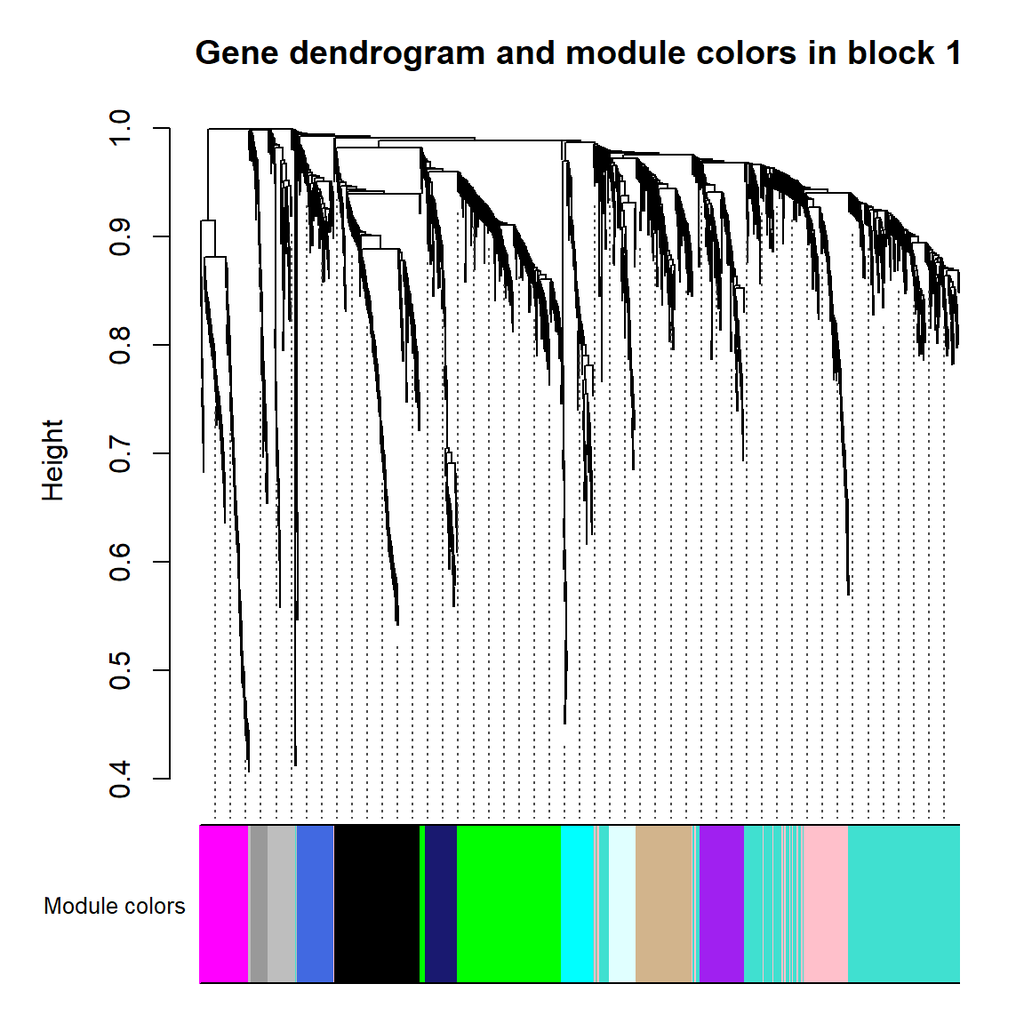

```r
# open a graphics window
#sizeGrWindow(6,6)
# Plot the dendrogram and the module colors underneath for block 1
plotDendroAndColors(bwnet$dendrograms[[1]], bwModuleColors[bwnet$blockGenes[[1]]],
"Module colors", main = "Gene dendrogram and module colors in block 1",
dendroLabels = FALSE, hang = 0.03,
addGuide = TRUE, guideHang = 0.05)
```

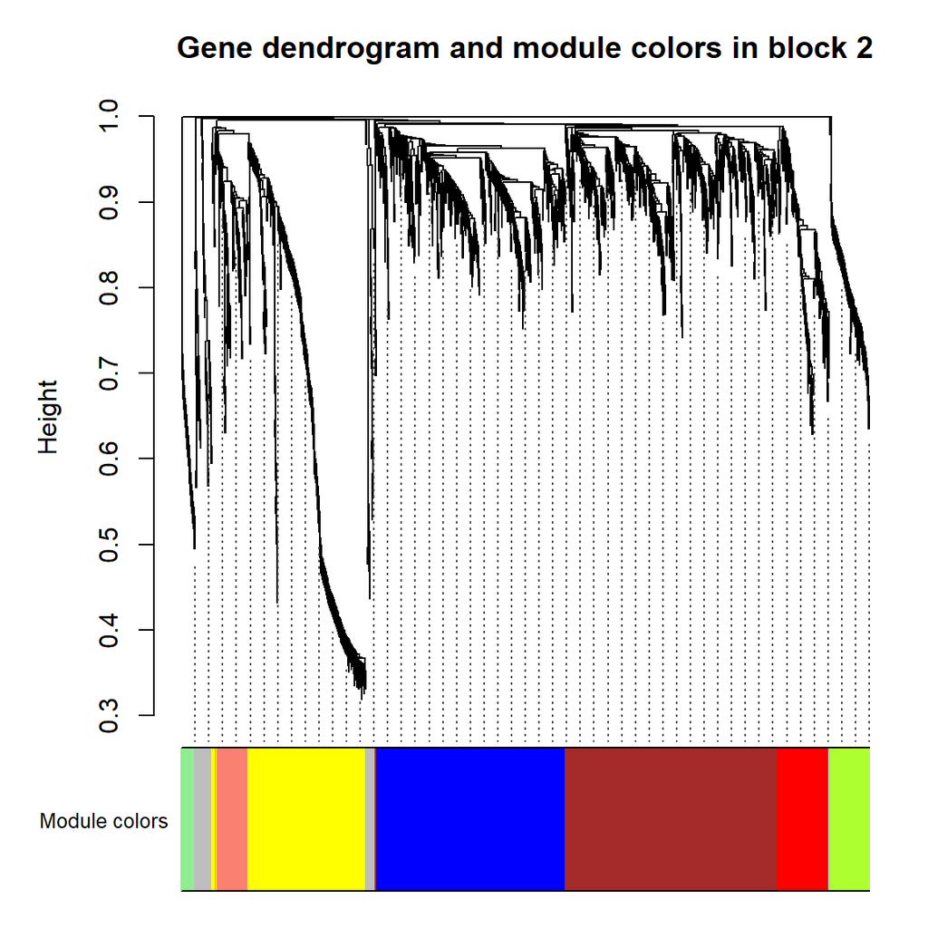

```r
# Plot the dendrogram and the module colors underneath for block 2
plotDendroAndColors(bwnet$dendrograms[[2]], bwModuleColors[bwnet$blockGenes[[2]]],
"Module colors", main = "Gene dendrogram and module colors in block 2",
dendroLabels = FALSE, hang = 0.03,
addGuide = TRUE, guideHang = 0.05)
```

## 3 Relating modules to external clinical traits and identifying important genes

**将模块与外部信息联系起来并识别重要基因**

参数设置与载入之前的分析结果:

```r
load(file = "FemaleLiver-01-dataInput.RData");
load(file = "FemaleLiver-02-networkConstruction-auto.RData")
```

### 3.a Quantifying module–trait associations

**3.a 量化模块-性状关联**

在这项分析中，我们希望确定与测量的临床特征显著相关的模块。由于我们已经为每个模块 有了一个概要文件（eigengene），我们只是简单地将特征基因与外部特征联系起来，并寻找 最重要的关联：

```r
# Define numbers of genes and samples
nGenes = ncol(datExpr);
nSamples = nrow(datExpr);
# Recalculate MEs with color labels
MEs0 = moduleEigengenes(datExpr, moduleColors)$eigengenes
MEs = orderMEs(MEs0)
moduleTraitCor = cor(MEs, datTraits, use = "p");
moduleTraitPvalue = corPvalueStudent(moduleTraitCor, nSamples)
```

由于我们有相当数量的模块和特征，一个合适的图形表示将有助于读取表。我们用相关值为 每个关联进行颜色编码：

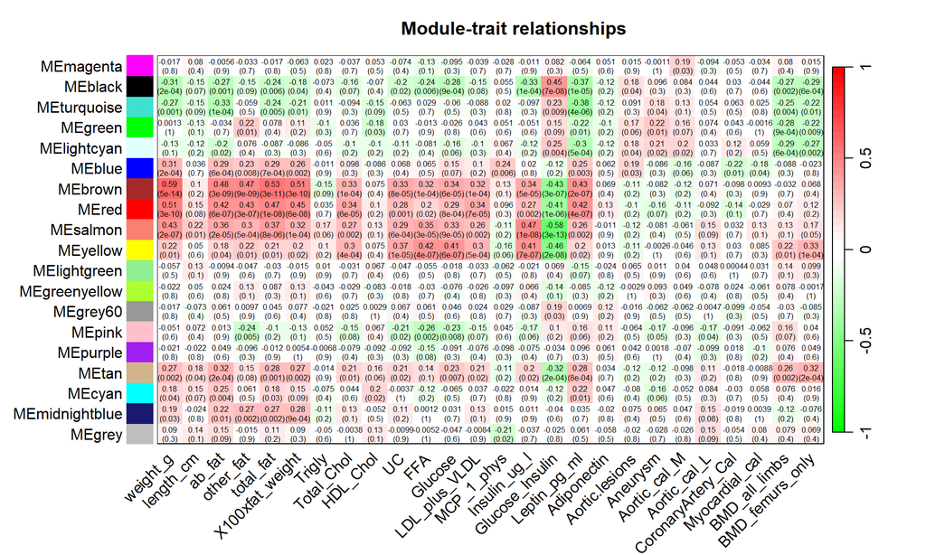

```r
#sizeGrWindow(10,6)
# 展示模块与表型数据的相关系数和 P值
textMatrix = paste(signif(moduleTraitCor, 2), "\n(",
                   signif(moduleTraitPvalue, 1), ")", sep = "");
dim(textMatrix) = dim(moduleTraitCor)
par(mar = c(6, 8.5, 3, 3));
# 用热图的形式展示相关系数
labeledHeatmap(Matrix = moduleTraitCor,
               xLabels = names(datTraits),
               yLabels = names(MEs),
               ySymbols = names(MEs),
               colorLabels = FALSE,
               colors = greenWhiteRed(50),
               textMatrix = textMatrix,
               setStdMargins = FALSE,
               cex.text = 0.5,
               zlim = c(-1,1),
               main = paste("Module-trait relationships"))
```

该分析确定了几个重要的模块-特征关联。我们将关注体重（weight）作为感兴趣的特征。

### 3.b Gene relationship to trait and important modules: Gene Significance and Module Membership

**3.b 基因与性状和重要模块的关系：Gene Significance 和 Module Membership**

我们通过定义 Gene Significance(GS) 为 gene 和 trait 的相关性，来量化单个基因与我们感兴趣的性状（体重weight）的关联。对于每个模块，我们定义 module membership(MM) 为 module eigengene 和 gene expression profile 的相关性。这使得我们能够量化阵列上的所有基因与每个模块的相似性。

```r
# Define variable weight containing the weight column of datTrait
weight = as.data.frame(datTraits$weight_g)
names(weight) = "weight"
# names (colors) of the modules
modNames = substring(names(MEs), 3)
geneModuleMembership = as.data.frame(cor(datExpr, MEs, use = "p"))
MMPvalue = as.data.frame(corPvalueStudent(as.matrix(geneModuleMembership), nSamples));
names(geneModuleMembership) = paste("MM", modNames, sep="")
names(MMPvalue) = paste("p.MM", modNames, sep="")
geneTraitSignificance = as.data.frame(cor(datExpr, weight, use = "p"))
GSPvalue = as.data.frame(corPvalueStudent(as.matrix(geneTraitSignificance), nSamples))
names(geneTraitSignificance) = paste("GS.", names(weight), sep="")
names(GSPvalue) = paste("p.GS.", names(weight), sep="")
```

### 3.c Intramodular analysis: identifying genes with high GS and MM

**3.c 模块内分析：识别具有高 GS 和 MM 的基因**

使用 GS 和 MM 测量方法，我们可以识别出对于 weight 有高显著性，并在感兴趣的模块中具有高模块成员身份的基因。作为一个例子，我们来看看与体重关联最高的棕色模块。

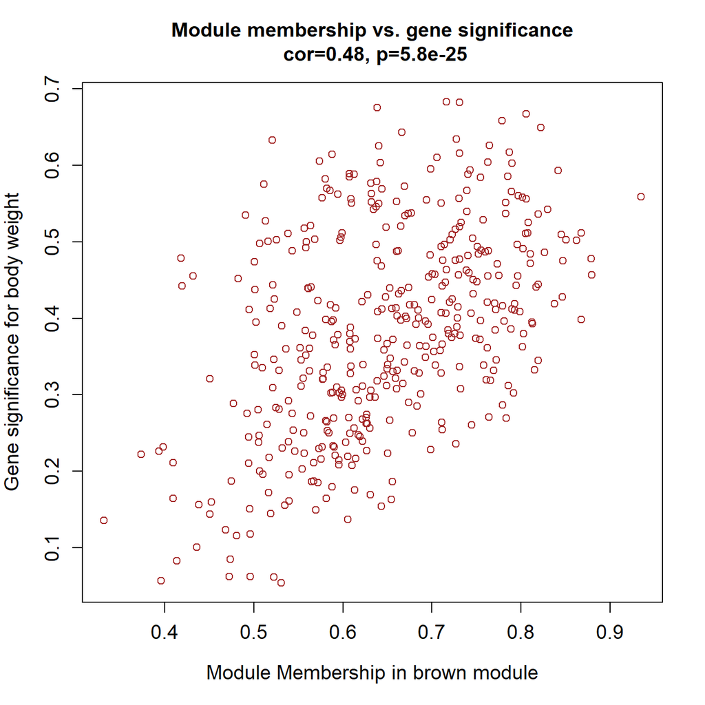

```r
module = "brown"
column = match(module, modNames);
moduleGenes = moduleColors==module;
#sizeGrWindow(7, 7);
par(mfrow = c(1,1));
verboseScatterplot(abs(geneModuleMembership[moduleGenes, column]),
                   abs(geneTraitSignificance[moduleGenes, 1]),
                   xlab = paste("Module Membership in", module, "module"),
                   ylab = "Gene significance for body weight",
                   main = paste("Module membership vs. gene significance\n"),
                   cex.main = 1.2, cex.lab = 1.2, cex.axis = 1.2, col = module)
```

### 3.d Summary output of network analysis results

**3.d 网络分析结果汇总输出**

我们已经发现了与我们感兴趣的特征有高度相关的模块，并通过模块成员度度量确定了它们 的核心参与者。我们现在将这些统计信息与基因注释合并，并写出一个总结最重要结果的文件，可以在标准电子表格软件如 MS Excel 或 Open Office Calc 中进行检查。 我们的表达量数据只用探针 ID 名称进行注释：命令

```r
#names(datExpr)#会返回所有在分析中的基因ID
#names(datExpr)[moduleColors=="brown"]#返回属于棕色模块的基因ID
annot = read.csv(file = "./FemaleLiver-Data/GeneAnnotation.csv");
dim(annot)
```

```
[1] 23388    34
```

```r
names(annot)
```

```
 [1] "X"                        "ID"
 [3] "arrayname"                "substanceBXH"
 [5] "gene_symbol"              "LocusLinkID"
 [7] "OfficialGeneSymbol"       "OfficialGeneName"
 [9] "LocusLinkSymbol"          "LocusLinkName"
[11] "ProteomeShortDescription" "UnigeneCluster"
[13] "LocusLinkCode"            "ProteomeID"
[15] "ProteomeCode"             "SwissprotID"
[17] "OMIMCode"                 "DirectedTilingPriority"
[19] "AlternateSymbols"         "AlternateNames"
[21] "SpeciesID"                "cytogeneticLoc"
[23] "Organism"                 "clustername"
[25] "reporterid"               "probeid"
[27] "sequenceid"               "clusterid"
[29] "chromosome"               "startcoordinate"
[31] "endcoordinate"            "strand"
[33] "sequence_3_to_5_prime"    "sequence_5_to_3_prime"
```

```r
probes = names(datExpr) # 匹配信息
probes2annot = match(probes, annot$substanceBXH);
sum(is.na(probes2annot)) # 检测是否有没有匹配上的ID号，正常来说为0，即全匹配上了。输出必要的信息：
```

```
[1] 0
```

```r
geneInfo0 = data.frame(substanceBXH = probes,
                       geneSymbol = annot$gene_symbol[probes2annot],
                       LocusLinkID = annot$LocusLinkID[probes2annot],
                       moduleColor = moduleColors,
                       geneTraitSignificance,
                       GSPvalue);
 #按照与体重的显著水平将模块进行排序:
 modOrder = order(-abs(cor(MEs, weight, use = "p")));
 #添加模块成员的信息：
 for (mod in 1:ncol(geneModuleMembership))
{
  oldNames = names(geneInfo0)
  geneInfo0 = data.frame(geneInfo0, geneModuleMembership[, modOrder[mod]],
                         MMPvalue[, modOrder[mod]]);
  names(geneInfo0) = c(oldNames, paste("MM.", modNames[modOrder[mod]], sep=""),
                       paste("p.MM.", modNames[modOrder[mod]], sep=""))
}
geneOrder = order(geneInfo0$moduleColor, -abs(geneInfo0$GS.weight));  # 排序
geneInfo = geneInfo0[geneOrder, ]
#输出为CSV格式，可用fix(geneInfo)在R中查看：
write.csv(geneInfo, file = "geneInfo.csv")
```

## 4 Interfacing network analysis with other data such as functional annotation and gene ontology

**将网络分析与其他数据（例如功能注释和 gene ontology）连接起来**

载入之前的分析结果:

```r
load(file = "FemaleLiver-01-dataInput.RData")
load(file = "FemaleLiver-02-networkConstruction-auto.RData")
```

我们之前的分析已经确定了几个与 weight 高度相关的模块（标记为 brown、red、salmon）。为了便于生物学解释，我们想知道模块中基因的 gene ontologies，它们是否在某些功能类别中显着富集等。

### 4.a Output gene lists for use with online software and services

**4.a 输出基因列表以供在线软件和服务使用**

一种选择是简单地导出 gene identifiers 列表，该列表可用作几种流行的 gene ontology 和功能富集分析套件（例如 David 或 AmiGO）的输入。例如，我们将 brown 模块的 LocusLinkID(entrez) 代码写入文件中：

```r
# Read in the probe annotation
annot = read.csv(file = "geneInfo.csv");
# Match probes in the data set to the probe IDs in the annotation file
probes = names(datExpr)
probes2annot = match(probes, annot$substanceBXH)
# Get the corresponding Locuis Link IDs
allLLIDs = annot$LocusLinkID[probes2annot];
# $ Choose interesting modules
intModules = c("brown", "red", "salmon")
for (module in intModules)
{
# Select module probes
modGenes = (moduleColors==module)
# Get their entrez ID codes
modLLIDs = allLLIDs[modGenes];
# Write them into a file
fileName = paste("LocusLinkIDs-", module, ".txt", sep="");
write.table(as.data.frame(modLLIDs), file = fileName,
row.names = FALSE, col.names = FALSE)
}
# As background in the enrichment analysis, we will use all probes in the analysis.
fileName = paste("LocusLinkIDs-all.txt", sep="");
write.table(as.data.frame(allLLIDs), file = fileName,
row.names = FALSE, col.names = FALSE)
```

### 4.b Enrichment analysis directly within R

**4.b 直接在 R 中进行富集分析**

WGCNA 包现在包含一个功能，可以使用简单的一步执行 GO 富集分析。要运行该函数，需要在运行此代码之前安装 Biconductor 包 GO.db、AnnotationDBI 和适当的物种特定注释包。特定于物种的包的名称格式为 org.Xx.eg.db，其中 Xx 代表生物体代码，例如，Mm 代表小鼠，Hs 代表人类等。唯一的例外是酵母，它没有 org.Xx.eg.db 包可用；相反，该包的名称为 org.Sc.sgd.db。请访问 Bioconductor 主页 http://www.bioconductor.org 下载并安装所需的软件包。在我们的例子中，我们正在研究小鼠的基因表达，因此此代码需要包 org.Mm.eg.db。调用 GO 富集分析函数 GOenrichmentAnalysis 非常简单。该函数采用模块标签向量，以及给定标签的基因的 Entrez（又名 Locus Link）编码。

```r
GOenr = GOenrichmentAnalysis(moduleColors, allLLIDs, organism = "mouse", nBestP = 10)
```

```
 GOenrichmentAnalysis: loading annotation data...
  ..of the 3038  Entrez identifiers submitted, 2844 are mapped in current GO categories.
  ..will use 2844 background genes for enrichment calculations.
  ..preparing term lists (this may take a while)..
  ..working on label set 1 ..
    ..calculating enrichments (this may also take a while)..
    ..putting together terms with highest enrichment significance..
```

```r
tab = GOenr$bestPTerms[[4]]$enrichment
names(tab)
```

```
 [1] "module"             "modSize"            "bkgrModSize"
 [4] "rank"               "enrichmentP"        "BonferoniP"
 [7] "nModGenesInTerm"    "fracOfBkgrModSize"  "fracOfBkgrTermSize"
[10] "bkgrTermSize"       "termID"             "termOntology"
[13] "termName"           "termDefinition"
```

```r
write.table(tab, file = "GOEnrichmentTable.csv", sep = ",", quote = TRUE, row.names = FALSE)
keepCols = c(1, 2, 5, 6, 7, 12, 13);
screenTab = tab[, keepCols];
# Round the numeric columns to 2 decimal places:
numCols = c(3, 4);
screenTab[, numCols] = signif(apply(screenTab[, numCols], 2, as.numeric), 2)
# Truncate the the term name to at most 40 characters
screenTab[, 7] = substring(screenTab[, 7], 1, 40)
# Shorten the column names:
colnames(screenTab) = c("module", "size", "p-val", "Bonf", "nInTerm", "ont", "term name");
rownames(screenTab) = NULL;
# Set the width of R’s output. The reader should play with this number to obtain satisfactory output.
options(width=95)
# Finally, display the enrichment table:
screenTab
```

| module | size | p-val | Bonf | nInTerm | ont | term name |
| --- | --- | --- | --- | --- | --- | --- |
| black | 166 | 6.1e-05 | 1.0e+00 | 15 | MF | signaling receptor activator activity |
| black | 166 | 6.1e-05 | 1.0e+00 | 15 | MF | receptor ligand activity |
| black | 166 | 1.3e-04 | 1.0e+00 | 15 | MF | signaling receptor regulator activity |
| black | 166 | 6.6e-04 | 1.0e+00 | 5 | BP | mRNA transport |
| black | 166 | 6.9e-04 | 1.0e+00 | 4 | BP | dopamine transport |
| black | 166 | 1.6e-03 | 1.0e+00 | 6 | BP | amine transport |
| black | 166 | 2.2e-03 | 1.0e+00 | 5 | BP | RNA transport |
| black | 166 | 2.6e-03 | 1.0e+00 | 2 | BP | ventricular compact myocardium morphogen |
| black | 166 | 2.6e-03 | 1.0e+00 | 2 | BP | regulation of corticotropin-releasing ho |
| black | 166 | 2.6e-03 | 1.0e+00 | 2 | BP | detection of chemical stimulus involved |
| blue | 428 | 0.0e+00 | 0.0e+00 | 145 | BP | immune response |
| blue | 428 | 0.0e+00 | 0.0e+00 | 188 | BP | immune system process |
| blue | 428 | 0.0e+00 | 0.0e+00 | 139 | BP | defense response |
| blue | 428 | 0.0e+00 | 0.0e+00 | 107 | BP | defense response to other organism |
| blue | 428 | 0.0e+00 | 0.0e+00 | 125 | BP | regulation of immune system process |
| blue | 428 | 0.0e+00 | 0.0e+00 | 126 | BP | response to external biotic stimulus |
| blue | 428 | 0.0e+00 | 0.0e+00 | 126 | BP | response to other organism |
| blue | 428 | 0.0e+00 | 0.0e+00 | 127 | BP | biological process involved in interspec |
| blue | 428 | 0.0e+00 | 0.0e+00 | 84 | BP | innate immune response |
| blue | 428 | 0.0e+00 | 0.0e+00 | 91 | BP | positive regulation of immune system pro |
| brown | 396 | 0.0e+00 | 0.0e+00 | 50 | CC | extracellular matrix |
| brown | 396 | 0.0e+00 | 0.0e+00 | 38 | CC | collagen-containing extracellular matrix |
| brown | 396 | 0.0e+00 | 0.0e+00 | 31 | MF | extracellular matrix structural constitu |
| brown | 396 | 0.0e+00 | 0.0e+00 | 124 | CC | extracellular region |
| brown | 396 | 0.0e+00 | 0.0e+00 | 35 | BP | extracellular matrix organization |
| brown | 396 | 0.0e+00 | 0.0e+00 | 63 | BP | vasculature development |
| brown | 396 | 0.0e+00 | 0.0e+00 | 61 | BP | blood vessel development |
| brown | 396 | 0.0e+00 | 0.0e+00 | 96 | CC | extracellular space |
| brown | 396 | 0.0e+00 | 1.0e-07 | 192 | CC | cell periphery |
| brown | 396 | 0.0e+00 | 1.0e-07 | 53 | BP | blood vessel morphogenesis |

[output cut: 160 more lines]

## 5 Network visualization using WGCNA functions

**5 使用 WGCNA 函数的网络可视化**

载入之前的分析结果:

```r
load(file = "FemaleLiver-01-dataInput.RData")
load(file = "FemaleLiver-02-networkConstruction-auto.RData")
```

### 5.a Visualizing the gene network

**5.a 基因网络可视化**

```r
# Calculate topological overlap anew: this could be done more efficiently by saving the TOM
# calculated during module detection, but let us do it again here.
dissTOM = 1-TOMsimilarityFromExpr(datExpr, power = 6);
```

```
TOM calculation: adjacency..
..will not use multithreading.
 Fraction of slow calculations: 0.396405
..connectivity..
..matrix multiplication (system BLAS)..
..normalization..
..done.
```

```r
# Transform dissTOM with a power to make moderately strong connections more visible in the heatmap
plotTOM = dissTOM^7;
# Set diagonal to NA for a nicer plot
diag(plotTOM) = NA;
# Call the plot function
sizeGrWindow(9,9)
TOMplot(plotTOM, geneTree, moduleColors, main = "Network heatmap plot, all genes")
```

[output not shown]

请注意，生成热图可能需要大量时间。可以限制基因数量以加快绘图速度；然而，基因子集的基因树状图通常看起来与所有基因的基因树状图不同。在下面的示例中，我们将绘制的基因数量限制为 400：

```r
nSelect = 400
# For reproducibility, we set the random seed
set.seed(10);
select = sample(nGenes, size = nSelect);
selectTOM = dissTOM[select, select];
# There’s no simple way of restricting a clustering tree to a subset of genes, so we must re-cluster.
selectTree = hclust(as.dist(selectTOM), method = "average")
selectColors = moduleColors[select];
# Open a graphical window
sizeGrWindow(9,9)
# Taking the dissimilarity to a power, say 10, makes the plot more informative by effectively changing
# the color palette; setting the diagonal to NA also improves the clarity of the plot
plotDiss = selectTOM^7;
diag(plotDiss) = NA;
TOMplot(plotDiss, selectTree, selectColors, main = "Network heatmap plot, selected genes")
```

[output not shown]

### 5.b Visualizing the network of eigengenes

**5.b 可视化 eigengenes 网络**

研究找到的模块之间的关系通常很有趣。人们可以使用特征基因（eigengenes）作为代表性概况，并通过特征基因相关性来量化模块相似性。该包包含一个方便的函数 `plotEigengeneNetworks` 生成特征基因网络的摘要图。将临床性状（或多个性状）添加到特征基因中，以了解这些特征如何适应特征基因网络，通常会提供丰富的信息：

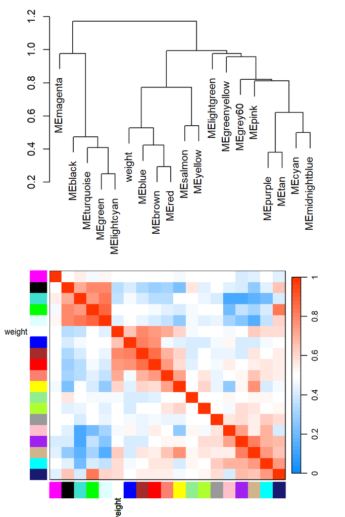

```r
# Recalculate module eigengenes
MEs = moduleEigengenes(datExpr, moduleColors)$eigengenes
# Isolate weight from the clinical traits
weight = as.data.frame(datTraits$weight_g);
names(weight) = "weight"
# Add the weight to existing module eigengenes4
MET = orderMEs(cbind(MEs, weight))
# Plot the relationships among the eigengenes and the trait
#sizeGrWindow(5,7.5);
par(cex = 0.9)
plotEigengeneNetworks(MET, "", marDendro = c(0,4,1,2), marHeatmap = c(3,4,1,2), cex.lab = 0.8, xLabelsAngle
= 90)
```

该函数生成特征基因和性状的树状图，以及它们关系的热图。要分割树状图和热图，我们可以使用以下代码

```r
# Plot the dendrogram
sizeGrWindow(6,6);
par(cex = 1.0)
plotEigengeneNetworks(MET, "Eigengene dendrogram", marDendro = c(0,4,2,0),
plotHeatmaps = FALSE)
# Plot the heatmap matrix (note: this plot will overwrite the dendrogram plot)
par(cex = 1.0)
plotEigengeneNetworks(MET, "Eigengene adjacency heatmap", marHeatmap = c(3,4,2,2),
plotDendrograms = FALSE, xLabelsAngle = 90)
```

## 6 Export of networks to external software

**6 将网络导出到外部软件**

载入之前的分析结果:

```r
load(file = "FemaleLiver-01-dataInput.RData")
load(file = "FemaleLiver-02-networkConstruction-auto.RData")
```

### 6.a Exporting to VisANT

**6.a 导出到 VisANT**

### 6.b Exporting to Cytoscape

**6.b 导出到 Cytoscape**